# sptfy

### SPOTIFY TÜRKİYE TOP200 ALBÜM ANALİZİ

Verinin Dahil Olduğu Tarih : 20-26 Mart 2026

Verinin Alındığı Site : Spotify Resmi Sayfası

https://charts.spotify.com/charts/view/album-tr-weekly/2026-03-26

Konu : Türkiye'de en çok dinlenen 200 albüm sıralaması

Yapan : Aydasu ÇELİK 24LITT034

# ÖZET

Bu projede Spotify Top 200 Albüm veri seti üzerinde keşifsel veri analizi gerçekleştirilmiştir. Python ve Pandas kullanılarak veri ön işleme işlemleri yapılmış, şarkı süreleri, müzik türleri, sanatçı dağılımları ve argo kullanımı gibi değişkenler incelenmiştir. Veri setinin genel yapısını anlamak amacıyla tanımsal istatistikler hesaplanmış, korelasyon ve aykırı değer analizleri uygulanmıştır. Elde edilen bulgular Matplotlib, Seaborn ve Plotly kullanılarak görselleştirilmiş, proje GitHub Pages üzerinden etkileşimli ve erişilebilir bir rapor olarak yayınlanmıştır.

```python
import pandas as pd
import matplotlib.pyplot as plt
import seaborn as sns
import matplotlib.patches as mpatches

spotify_green = "#1DB954"
```

```python
df = pd.read_excel(r"C:\Users\celik\ist programlama\spotify_top200_veri_analizi\data\sptfy.xlsx")
```

```python
df["ŞARKI TÜRÜ"] = df["ŞARKI TÜRÜ"].astype(str).str.strip().str.upper()
df["ARGO VAR MI?"] = df["ARGO VAR MI?"].astype(str).str.strip()
df["ÇIKIŞ TARİHİ"] = pd.to_datetime(df["ÇIKIŞ TARİHİ"])
df["YIL"] = df["ÇIKIŞ TARİHİ"].dt.year
```

```python
df.head()
```

|  | ALBÜM ADI | SANATÇI | ÇIKIŞ TARİHİ | ŞARKI ADI | ŞARKI SÜRESİ(SANİYE) | ŞARKI SIRASI | ARGO VAR MI? | ŞARKI TÜRÜ | YIL |
| --- | --- | --- | --- | --- | --- | --- | --- | --- | --- |
| 0 | ARIRANG | BTS | 2026-03-20 | Body to Body | 190 | 1 | Hayır | K-POP | 2026 |
| 1 | ARIRANG | BTS | 2026-03-20 | Hooligan | 168 | 2 | Hayır | K-POP | 2026 |
| 2 | ARIRANG | BTS | 2026-03-20 | Aliens | 181 | 3 | Hayır | K-POP | 2026 |
| 3 | ARIRANG | BTS | 2026-03-20 | FYA | 170 | 4 | Hayır | K-POP | 2026 |
| 4 | ARIRANG | BTS | 2026-03-20 | 2.0 | 98 | 5 | Hayır | K-POP | 2026 |

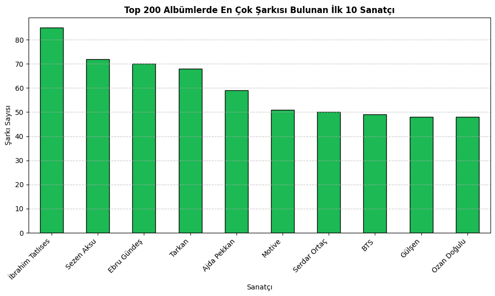

```python
#En Çok Şarkısı Bulunan İlk 10 Sanatçı
plt.figure(figsize=(10, 6))
df["SANATÇI"].value_counts().head(10).plot(kind="bar", color=spotify_green, edgecolor="black")

plt.title("Top 200 Albümlerde En Çok Şarkısı Bulunan İlk 10 Sanatçı", fontweight="bold")
plt.xlabel("Sanatçı")
plt.ylabel("Şarkı Sayısı")
plt.xticks(rotation=45, ha="right")
plt.grid(axis='y', linestyle='--', alpha=0.7)

plt.tight_layout()
plt.show()
```

### Şekil 1. Top 200 Albümlerde En Çok Şarkısı Bulunan İlk 10 Sanatçı

En yüksek değer (85) ile en düşük değer (48) arasında yaklaşık 37 şarkılık fark bulunmaktadır. Lider sanatçı olan İbrahim Tatlıses, son sıradaki sanatçıya göre yaklaşık %77 daha fazla temsil edilmiştir.

Bu durum, Top 200 albümler içerisinde belirli sanatçıların diğerlerine kıyasla daha yoğun temsil edildiğini göstermektedir. Özellikle İbrahim Tatlıses, Sezen Aksu, Ebru Gündeş ve Tarkan listenin üst sıralarında yer almaktadır.

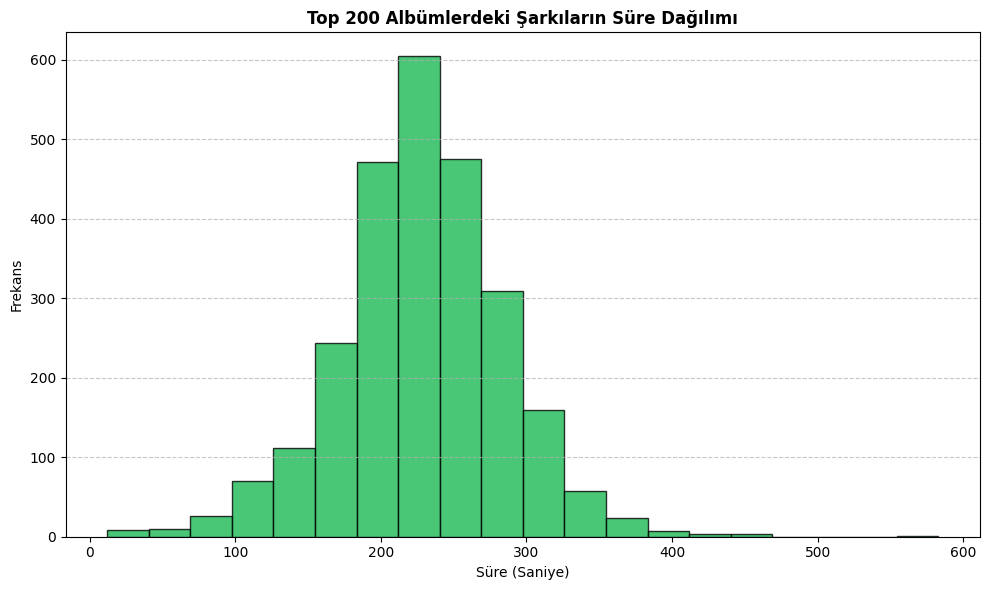

```python
#Şarkı Süreleri Dağılımı
plt.figure(figsize=(10, 6))
plt.hist(df["ŞARKI SÜRESİ(SANİYE)"], bins=20, color=spotify_green, edgecolor="black", alpha=0.8)

plt.title("Top 200 Albümlerdeki Şarkıların Süre Dağılımı", fontweight="bold")
plt.xlabel("Süre (Saniye)")
plt.ylabel("Frekans")
plt.grid(axis='y', linestyle='--', alpha=0.7)

plt.tight_layout()
plt.show()
```

### Şekil 2. Top 200 Albümlerdeki Şarkıların Süre Dağılımı

Histogram incelendiğinde şarkı sürelerinin yaklaşık olarak normal dağılıma benzer bir yapı gösterdiği görülmektedir. Dağılımın en yoğun olduğu aralık 200–250 saniye olup, şarkıların büyük çoğunluğu 150–300 saniye arasında yer almaktadır.

Dağılım tek tepeli bir yapıya sahiptir ve gözlemler belirli bir merkez etrafında kümelenmektedir. Çok kısa süreli (100 saniyenin altı) ve çok uzun süreli (400 saniyenin üzeri) şarkılar ise oldukça düşük frekansta gözlenmektedir. Bu durum, Top 200 albümlerde yer alan şarkıların genel olarak benzer sürelerde üretildiğini ve müzik sektöründe yaygın olan standart şarkı süresi aralığında yoğunlaştığını göstermektedir.

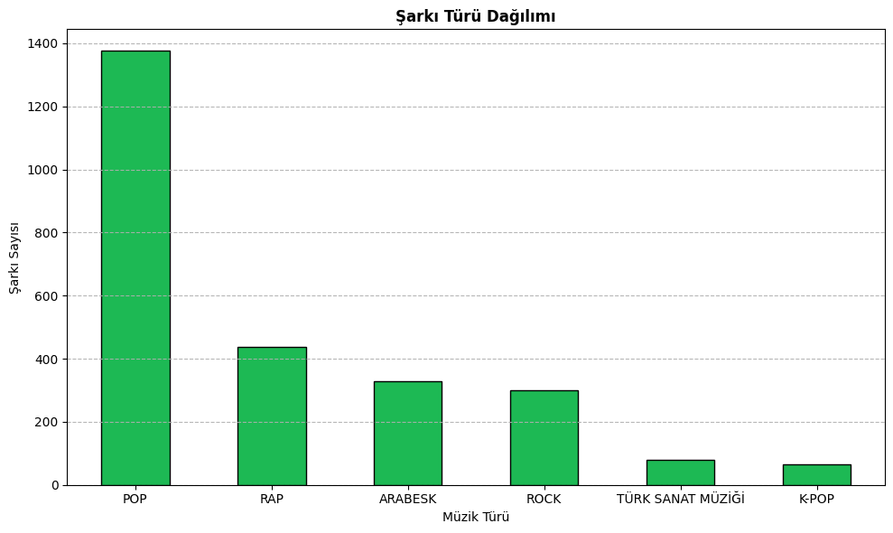

```python
#Şarkı Türlerine Göre Dağılım
plt.figure(figsize=(10, 6))
df["ŞARKI TÜRÜ"].value_counts().plot(kind="bar", color=spotify_green, edgecolor="black")

plt.title("Şarkı Türü Dağılımı", fontweight="bold")
plt.xlabel("Müzik Türü")
plt.ylabel("Şarkı Sayısı")
plt.xticks(rotation=0)
plt.grid(axis='y', linestyle='--', alpha=0.9)

plt.tight_layout()
plt.show()
```

### Şekil 3. Şarkı Türü Dağılımı

Grafik incelendiğinde en baskın müzik türünün açık ara POP olduğu görülmektedir. POP türündeki şarkı sayısı diğer türlere kıyasla oldukça yüksek olup, veri setinin büyük bir bölümünü oluşturmaktadır. POP türünü sırasıyla RAP, ARABESK ve ROCK türleri takip etmektedir.

Türler arasındaki dağılım dengeli değildir. Veri setinde belirli türlerin yoğun olarak temsil edildiği, bazı türlerin ise oldukça düşük frekanslarda yer aldığı görülmektedir. Özellikle Türk Sanat Müziği, K-Pop ve diğer alt türler toplam şarkı sayısı içerisinde sınırlı bir paya sahiptir. Bu durum, Top 200 albümlerin ağırlıklı olarak popüler müzik türlerinden oluştuğunu ve dinleyici tercihlerinin belirli türler üzerinde yoğunlaştığını göstermektedir.

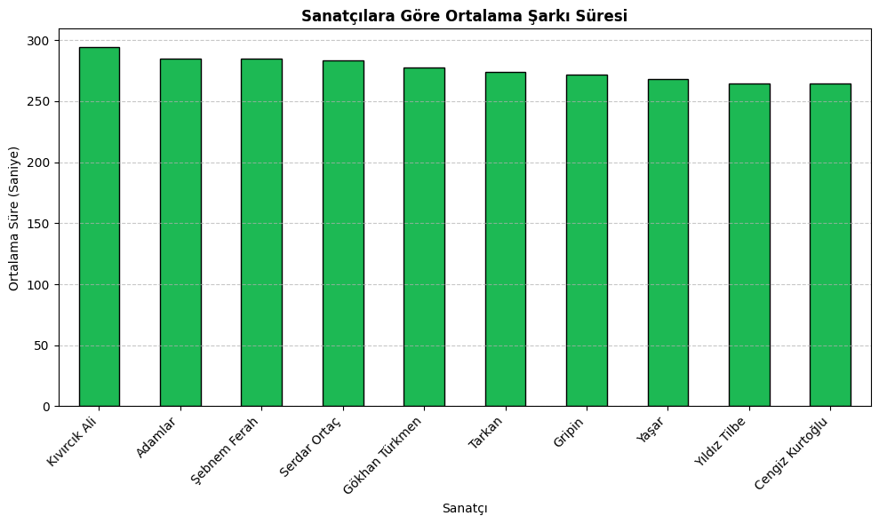

```python
#Sanatçılara Göre Ortalama Şarkı Süresi (İlk 10)
plt.figure(figsize=(10, 6))
df.groupby("SANATÇI")["ŞARKI SÜRESİ(SANİYE)"].mean().sort_values(ascending=False).head(10).plot(kind="bar", color=spotify_green, edgecolor="black")

plt.title("Sanatçılara Göre Ortalama Şarkı Süresi", fontweight="bold")
plt.xlabel("Sanatçı")
plt.ylabel("Ortalama Süre (Saniye)")
plt.xticks(rotation=45, ha="right")
plt.grid(axis='y', linestyle='--', alpha=0.7)

plt.tight_layout()
plt.show()
```

### Şekil 4. Sanatçılara Göre Ortalama Şarkı Süresi

Grafik incelendiğinde sanatçıların ortalama şarkı sürelerinin birbirine oldukça yakın olduğu görülmektedir. Ortalama süreler yaklaşık 260 ile 295 saniye arasında değişmekte olup, sanatçılar arasında belirgin bir farklılık bulunmamaktadır.

En yüksek ortalama şarkı süresine Kıvırcık Ali sahipken, onu Adamlar, Şebnem Ferah ve Serdar Ortaç takip etmektedir. En düşük ortalama şarkı süreleri ise Yıldız Tilbe ve Cengiz Kurtoğlu'na aittir. Ancak en yüksek ve en düşük değerler arasındaki fark yaklaşık 30 saniye olduğundan, sanatçılar arasında şarkı süresi bakımından büyük bir ayrışma olmadığı söylenebilir.

Bu sonuç, farklı müzik türlerinden sanatçıların yer almasına rağmen şarkı sürelerinin genel olarak benzer bir aralıkta yoğunlaştığını ve dinleyici alışkanlıklarına uygun standart sürelerde üretildiğini göstermektedir.

Grafikte yer alan sanatçıların ortalama şarkı sürelerinin birbirine oldukça yakın olması, şarkı süresi açısından düşük varyasyona işaret etmektedir.

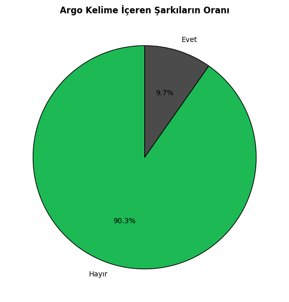

```python
#Argo Kullanım Oranı
plt.figure(figsize=(6, 6))
argo_counts = df["ARGO VAR MI?"].value_counts()

plt.pie(argo_counts, labels=argo_counts.index, autopct='%1.1f%%', startangle=90,
        colors=[spotify_green, "#4b4b4b"], wedgeprops={'edgecolor': 'black'})

plt.title("Argo Kelime İçeren Şarkıların Oranı", fontweight="bold")
plt.tight_layout()
plt.show()
```

### Şekil 5. Argo Kelime İçeren Şarkıların Oranı

Grafik incelendiğinde veri setinde yer alan şarkıların büyük çoğunluğunun argo kelime içermediği görülmektedir. Şarkıların %90,3'ü argo kelime içermezken, yalnızca %9,7'sinde argo kelime kullanımı tespit edilmiştir.

Argo kelime içeren şarkıların oranının düşük olması, Top 200 albümlerde yer alan eserlerin genel olarak daha yaygın ve geniş dinleyici kitlesine hitap eden bir dil kullandığını göstermektedir. Buna karşılık, argo kullanımının tamamen ortadan kalkmadığı ve belirli bir oranda şarkı sözlerinde yer aldığı da görülmektedir.

Bu sonuç, veri setindeki şarkı sözlerinin büyük ölçüde standart ve genel kabul gören bir dil yapısına sahip olduğunu, argo ifadelerin ise sınırlı düzeyde kullanıldığını göstermektedir.

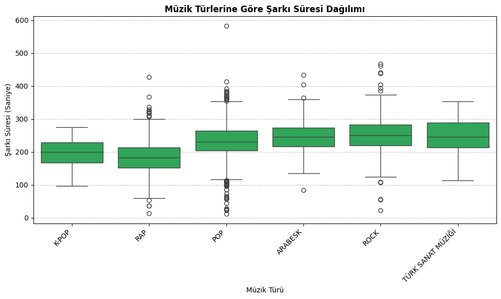

```python
plt.figure(figsize=(10, 6))

sns.boxplot(
    data=df,
    x="ŞARKI TÜRÜ",
    y="ŞARKI SÜRESİ(SANİYE)",
    color=spotify_green
)

plt.title("Müzik Türlerine Göre Şarkı Süresi Dağılımı", fontweight="bold")
plt.xlabel("Müzik Türü")
plt.ylabel("Şarkı Süresi (Saniye)")
plt.xticks(rotation=45, ha="right")
plt.grid(axis="y", linestyle="--", alpha=0.7)

plt.tight_layout()
plt.show()
```

### Şekil 6. Müzik Türlerine Göre Şarkı Süresi Dağılımı

Kutu grafiği incelendiğinde müzik türlerine ait şarkı sürelerinin dağılımlarının birbirinden farklılık gösterdiği görülmektedir. Bazı türlerde medyan değer daha yüksekken, bazı türlerde dağılım daha geniş bir aralığa yayılmıştır.

Grafikte yer alan aykırı değerler, ilgili türlerde ortalamadan belirgin şekilde uzun veya kısa şarkıların bulunduğunu göstermektedir. Bu durum, şarkı sürelerinin türlere göre değişkenlik gösterebildiğini ortaya koymaktadır.

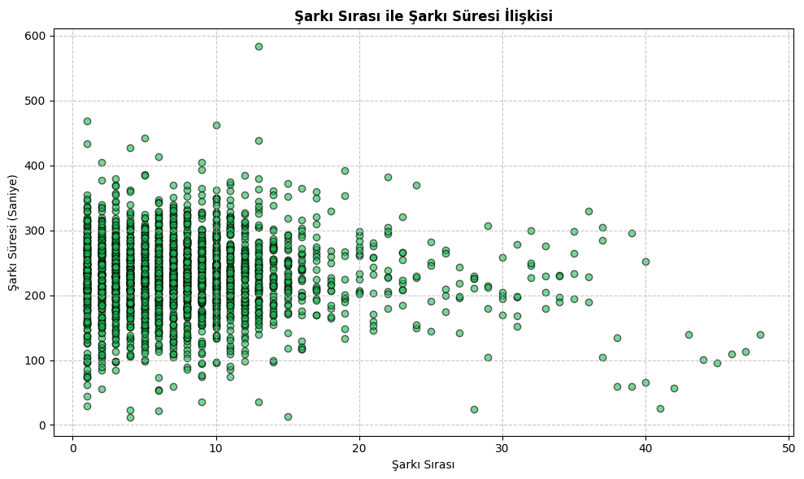

```python
plt.figure(figsize=(10, 6))

plt.scatter(
    df["ŞARKI SIRASI"],
    df["ŞARKI SÜRESİ(SANİYE)"],
    color=spotify_green,
    alpha=0.6,
    edgecolor="black"
)

plt.title("Şarkı Sırası ile Şarkı Süresi İlişkisi", fontweight="bold")
plt.xlabel("Şarkı Sırası")
plt.ylabel("Şarkı Süresi (Saniye)")
plt.grid(linestyle="--", alpha=0.7)

plt.tight_layout()
plt.show()
```

### Şekil 7. Şarkı Sırası ile Şarkı Süresi İlişkisi

Dağılım grafiği incelendiğinde şarkı sırası ile şarkı süresi arasında belirgin bir doğrusal ilişki gözlenmemektedir. Noktaların grafik üzerinde dağınık bir şekilde yer alması, şarkının albüm içerisindeki sırasının süresini doğrudan etkilemediğini göstermektedir.

Bu sonuç, albümlerde yer alan şarkıların sürelerinin sıralamadan bağımsız olarak belirlendiğine işaret etmektedir.

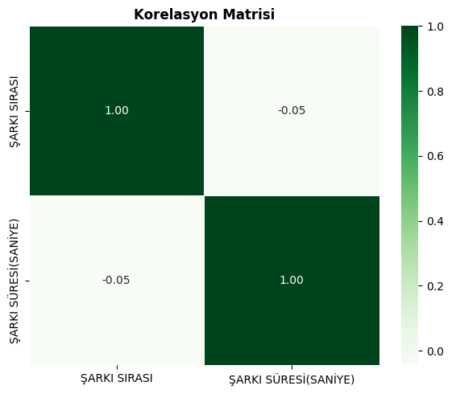

```python
plt.figure(figsize=(6, 5))

corr = df[["ŞARKI SIRASI", "ŞARKI SÜRESİ(SANİYE)"]].corr()

sns.heatmap(
    corr,
    annot=True,
    cmap="Greens",
    linewidths=0.5,
    fmt=".2f"
)

plt.title("Korelasyon Matrisi", fontweight="bold")

plt.tight_layout()
plt.show()
```

### Şekil 8. Korelasyon Matrisi

Korelasyon matrisi incelendiğinde şarkı sırası ile şarkı süresi arasındaki ilişkinin oldukça zayıf olduğu görülmektedir. Korelasyon katsayısının sıfıra yakın olması, değişkenler arasında güçlü bir doğrusal ilişki bulunmadığını göstermektedir.

Bu sonuç, albümlerde yer alan şarkıların sıralarının şarkı süreleri üzerinde belirgin bir etkisi olmadığını ortaya koymaktadır.

```python
df["ARGO"] = (df["ARGO VAR MI?"] == "Evet").astype(int)
```

```python
corr = df[[
    "ŞARKI SIRASI",
    "ŞARKI SÜRESİ(SANİYE)",
    "ARGO"
]].corr()
```

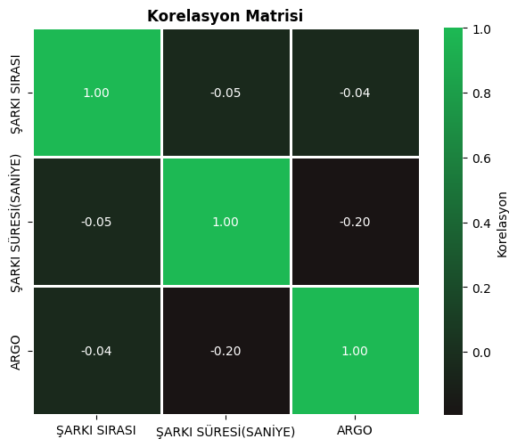

```python
from matplotlib.colors import LinearSegmentedColormap

spotify_cmap = LinearSegmentedColormap.from_list(
    "spotify",
    ["#191414", "#1DB954"]
)

plt.figure(figsize=(6, 5))

sns.heatmap(
    corr,
    annot=True,
    cmap=spotify_cmap,
    linewidths=1,
    linecolor="white",
    fmt=".2f",
    square=True,
    cbar_kws={"label": "Korelasyon"}
)

plt.title("Korelasyon Matrisi", fontweight="bold")

plt.tight_layout()
plt.show()
```

### Şekil 9. Korelasyon Matrisi

Korelasyon matrisi incelendiğinde değişkenler arasında güçlü bir doğrusal ilişki bulunmadığı görülmektedir. Şarkı sırası ile şarkı süresi arasındaki korelasyon katsayısı -0,05 olarak hesaplanmıştır. Bu değer sıfıra oldukça yakın olduğundan iki değişken arasında anlamlı bir ilişki bulunmamaktadır.

Benzer şekilde şarkı sırası ile argo kullanımı arasındaki korelasyon katsayısı -0,04 olup ilişkinin oldukça zayıf olduğu görülmektedir. Şarkı süresi ile argo kullanımı arasındaki korelasyon katsayısı ise -0,20 olarak hesaplanmıştır. Bu değer diğer ilişkilere kıyasla daha yüksek olmakla birlikte hâlâ zayıf negatif korelasyon düzeyindedir.

Sonuç olarak veri setindeki değişkenlerin büyük ölçüde birbirinden bağımsız hareket ettiği ve aralarında güçlü bir doğrusal ilişki bulunmadığı söylenebilir.

```python
df["ŞARKI SÜRESİ(SANİYE)"].describe()
```

```
count    2586.000000
mean      227.957077
std        56.950989
min        12.000000
25%       195.250000
50%       228.000000
75%       263.000000
max       583.000000
Name: ŞARKI SÜRESİ(SANİYE), dtype: float64
```

## Tanımsal İstatistik 1: Şarkı Sürelerinin Genel Özeti

Veri setinde toplam 2586 şarkı bulunmaktadır. Şarkı sürelerinin ortalaması 227,96 saniye, medyanı ise 228 saniye olarak hesaplanmıştır. Ortalama ve medyan değerlerinin birbirine oldukça yakın olması, dağılımın genel olarak dengeli olduğunu göstermektedir.

En kısa şarkı 12 saniye, en uzun şarkı ise 583 saniyedir. Standart sapmanın 56,95 saniye olması şarkı sürelerinde belirli bir değişkenlik bulunduğunu göstermektedir.

```python
df.groupby("ŞARKI TÜRÜ")["ŞARKI SÜRESİ(SANİYE)"].agg(
    ["count", "mean", "median", "std", "min", "max"]
)
```

| ŞARKI TÜRÜ | count | mean | median | std | min | max |
| --- | --- | --- | --- | --- | --- | --- |
| ARABESK | 330 | 246.221212 | 246.0 | 45.670581 | 84 | 433 |
| K-POP | 64 | 196.765625 | 199.0 | 39.622321 | 97 | 275 |
| POP | 1376 | 232.596657 | 231.0 | 52.357242 | 12 | 583 |
| RAP | 437 | 183.828375 | 183.0 | 55.007300 | 13 | 427 |
| ROCK | 301 | 252.109635 | 251.0 | 58.243895 | 23 | 468 |
| TÜRK SANAT MÜZİĞİ | 78 | 248.461538 | 245.5 | 54.836402 | 114 | 353 |

## Tanımsal İstatistik 2: Türlere Göre Şarkı Süreleri

Tür bazında yapılan incelemede en yüksek ortalama şarkı süresinin ROCK türünde (252 saniye), en düşük ortalama sürenin ise RAP türünde (184 saniye) olduğu görülmüştür. POP türü 233 saniye ortalama ile veri setindeki genel ortalamaya yakın bir değer göstermektedir.

Sonuçlar, müzik türlerinin şarkı süreleri üzerinde belirli düzeyde farklılık oluşturduğunu göstermektedir.

```python
df["ŞARKI TÜRÜ"].value_counts()
```

```
ŞARKI TÜRÜ
POP                  1376
RAP                   437
ARABESK               330
ROCK                  301
TÜRK SANAT MÜZİĞİ      78
K-POP                  64
Name: count, dtype: int64
```

## Tanımsal İstatistik 3: Şarkı Türlerinin Frekans Dağılımı

Şarkı türlerinin frekans dağılımı incelendiğinde veri setinin büyük ölçüde POP müzik türü etrafında yoğunlaştığı görülmektedir. Veri setinde yer alan 2586 şarkının 1376'sı POP türünde olup toplam gözlemlerin yarısından fazlasını oluşturmaktadır.

POP türünü sırasıyla RAP (437), ARABESK (330) ve ROCK (301) takip etmektedir. TÜRK SANAT MÜZİĞİ (78) ve K-POP (64) ise veri setinde en az temsil edilen türlerdir. Bu durum, veri setinin ağırlıklı olarak popüler müzik türlerinden oluştuğunu göstermektedir.

```python
df["SANATÇI"].value_counts().head(10)
```

```
SANATÇI
İbrahim Tatlıses    85
Sezen Aksu          72
Ebru Gündeş         70
Tarkan              68
Ajda Pekkan         59
Motive              51
Serdar Ortaç        50
BTS                 49
Gülşen              48
Ozan Doğulu         48
Name: count, dtype: int64
```

## Tanımsal İstatistik 4: Sanatçı Frekansları

Sanatçı bazında yapılan incelemede veri setinde en fazla temsil edilen sanatçının 85 şarkı ile İbrahim Tatlıses olduğu görülmektedir. İbrahim Tatlıses'i sırasıyla Sezen Aksu (72), Ebru Gündeş (70), Tarkan (68) ve Ajda Pekkan (59) takip etmektedir.

```python
Q1 = df["ŞARKI SÜRESİ(SANİYE)"].quantile(0.25)
Q3 = df["ŞARKI SÜRESİ(SANİYE)"].quantile(0.75)

IQR = Q3 - Q1

alt_sinir = Q1 - 1.5 * IQR
ust_sinir = Q3 + 1.5 * IQR

aykiri = df[
    (df["ŞARKI SÜRESİ(SANİYE)"] < alt_sinir)
    | (df["ŞARKI SÜRESİ(SANİYE)"] > ust_sinir)
]

print("Aykırı gözlem sayısı:", len(aykiri))
```

```
Aykırı gözlem sayısı: 63
```

## Tanımsal İstatistik 5: Aykırı Değer Analizi

IQR (Interquartile Range - Çeyrekler Arası Aralık) yöntemi kullanılarak yapılan analiz sonucunda veri setinde 63 adet aykırı gözlem tespit edilmiştir. Bu değer toplam gözlemlerin yaklaşık %2,4'üne karşılık gelmektedir.

Aykırı gözlemler genellikle olağan dışı derecede kısa veya uzun şarkıları temsil etmektedir. Ancak aykırı değerlerin oranının düşük olması, veri setinin genel yapısının tutarlı olduğunu ve gözlemlerin büyük çoğunluğunun benzer bir dağılım gösterdiğini ortaya koymaktadır.

# Bulgular

- Veri setinde toplam 2586 şarkı yer almaktadır. Şarkı sürelerinin ortalaması 227,96 saniye, medyanı ise 228 saniye olarak hesaplanmıştır. Ortalama ve medyan değerlerinin birbirine oldukça yakın olması, şarkı sürelerinin dengeli bir dağılım gösterdiğine işaret etmektedir.
- Veri setindeki şarkıların büyük çoğunluğu 150 ile 300 saniye arasında yoğunlaşmaktadır. Histogram analizi, şarkı sürelerinin yaklaşık olarak normal dağılıma benzer bir yapı sergilediğini göstermektedir.
- En baskın müzik türü 1376 şarkı ile POP'tur. POP türü tek başına veri setindeki tüm şarkıların yarısından fazlasını oluşturmaktadır. RAP, ARABESK ve ROCK türleri ise veri setinde önemli bir paya sahip diğer türlerdir.
- Tür bazında yapılan incelemede en yüksek ortalama şarkı süresinin ROCK türünde (252 saniye), en düşük ortalama sürenin ise RAP türünde (184 saniye) olduğu belirlenmiştir. Bu durum müzik türlerinin şarkı süreleri üzerinde etkili olduğunu göstermektedir.
- Veri setinde en fazla temsil edilen sanatçı 85 şarkı ile İbrahim Tatlıses'tir. Sezen Aksu, Ebru Gündeş ve Tarkan ise en sık yer alan diğer sanatçılar arasında bulunmaktadır.
- Şarkıların %90,3'ünde argo kelime kullanımına rastlanmazken yalnızca %9,7'sinde argo kullanımına rastlanmıştır. Bu sonuç, veri setindeki şarkı sözlerinin genel olarak standart ve geniş kitlelere hitap eden bir dil yapısına sahip olduğunu göstermektedir.
- Korelasyon analizi sonucunda şarkı sırası, şarkı süresi ve argo kullanımı değişkenleri arasında güçlü bir doğrusal ilişki bulunmadığı tespit edilmiştir. En yüksek korelasyon değeri -0,20 olup bu değer dahi zayıf ilişki düzeyindedir.
- IQR yöntemi ile gerçekleştirilen aykırı değer analizinde 63 adet aykırı gözlem belirlenmiştir. Bu gözlemler toplam veri setinin yaklaşık %2,4'ünü oluşturmakta olup veri setinin genel yapısını önemli ölçüde etkileyecek düzeyde değildir.

```python
ticaret_gold = "#FFC600"
ticaret_navy = "#1F2A37"
```

```python
import plotly.express as px
import plotly.io as pio
pio.renderers.default = "notebook"
from IPython.display import HTML, display

tur_sayim = df["ŞARKI TÜRÜ"].value_counts().reset_index()
tur_sayim.columns = ["Tür", "Şarkı Sayısı"]

fig = px.bar(
    tur_sayim,
    x="Tür",
    y="Şarkı Sayısı",
    text="Şarkı Sayısı",
    title="Şarkı Türlerine Göre Dağılım"
)

fig.update_traces(
    marker_color=ticaret_gold,
    marker_line_color=ticaret_navy,
    marker_line_width=1.5,
    textposition="outside"
)

fig.update_layout(
    title_x=0.5,
    plot_bgcolor="white",
    paper_bgcolor="white",
    font=dict(color=ticaret_navy),
    xaxis_title="Müzik Türü",
    yaxis_title="Şarkı Sayısı"
)

fig.show()
```

[interactive chart not shown]

### Plotly Grafik 1. Şarkı Türlerine Göre Dağılım

Etkileşimli grafik incelendiğinde veri setinin büyük ölçüde POP müzik türü etrafında yoğunlaştığı görülmektedir. Toplam 1376 şarkı ile POP türü veri setindeki tüm şarkıların yarısından fazlasını oluşturmaktadır. POP türünü sırasıyla RAP (437), ARABESK (330) ve ROCK (301) takip etmektedir.

TÜRK SANAT MÜZİĞİ (78) ve K-POP (64) ise veri setinde en az temsil edilen türlerdir. Bu durum, Spotify Top 200 albümlerinin ağırlıklı olarak popüler müzik türlerinden oluştuğunu ve dinleyici tercihlerinin belirli türler üzerinde yoğunlaştığını göstermektedir.

```python
yil_album = (
    df.groupby("YIL")["ALBÜM ADI"]
    .nunique()
    .reset_index()
)

yil_album.columns = ["Yıl", "Albüm Sayısı"]

fig = px.line(
    yil_album,
    x="Yıl",
    y="Albüm Sayısı",
    markers=True,
    title="Yıllara Göre Albüm Sayısı"
)

fig.update_traces(
    line_color=ticaret_gold,
    line_width=4,
    marker=dict(
        color=ticaret_navy,
        size=9
    )
)

fig.update_layout(
    title_x=0.5,
    plot_bgcolor="white",
    paper_bgcolor="white",
    font=dict(color=ticaret_navy),
    xaxis_title="Yıl",
    yaxis_title="Albüm Sayısı"
)

fig.show()
```

[interactive chart not shown]

### Plotly Grafik 2. Yıllara Göre Albüm Sayısı

Etkileşimli çizgi grafik incelendiğinde veri setinde yer alan albümlerin çıkış yıllarına göre dağılımının zaman içerisinde değişiklik gösterdiği görülmektedir. 1970'li ve 1980'li yıllarda veri setinde sınırlı sayıda albüm bulunurken, 2000'li yıllardan itibaren albüm sayılarında belirgin bir artış gözlenmektedir.

Özellikle 2010 yılı sonrasında veri setindeki albüm yoğunluğu dikkat çekmektedir. En yüksek albüm sayısı yaklaşık 19 albüm ile 2024 yılında görülmektedir. Bu durum, veri setinin büyük ölçüde güncel ve yakın dönem müzik çalışmalarından oluştuğunu göstermektedir.

Genel olarak grafik, Spotify Top 200 albümlerinin ağırlıklı olarak son yıllarda yayımlanan eserlerden oluştuğunu ve güncel müzik içeriklerinin veri setinde daha fazla temsil edildiğini ortaya koymaktadır.

# Sonuç

Bu çalışmada Spotify Top 200 Albüm veri seti üzerinde keşifsel veri analizi gerçekleştirilmiş ve veri setinin temel özellikleri çeşitli istatistiksel yöntemler ve görselleştirme teknikleri kullanılarak incelenmiştir. Analiz sürecinde şarkı süreleri, müzik türleri, sanatçı dağılımları, argo kullanımı ve değişkenler arasındaki ilişkiler değerlendirilmiştir.

Elde edilen bulgular, veri setinin büyük ölçüde POP müzik türü etrafında yoğunlaştığını göstermiştir. Toplam 2586 şarkının yarısından fazlası POP türünde yer almakta olup, RAP, ARABESK ve ROCK türleri veri setinde önemli paya sahip diğer müzik türleri olarak öne çıkmaktadır. Tür bazında yapılan incelemelerde ROCK türünün ortalama şarkı süresinin en yüksek, RAP türünün ise en düşük olduğu belirlenmiştir.

Şarkı süreleri incelendiğinde ortalama sürenin 227,96 saniye, medyan sürenin ise 228 saniye olduğu görülmüştür. Bu iki değerin birbirine oldukça yakın olması, veri setinin dengeli bir dağılım sergilediğini göstermektedir. Histogram ve kutu grafiği analizleri, şarkıların büyük bölümünün belirli bir süre aralığında yoğunlaştığını, yalnızca sınırlı sayıda gözlemin olağan dışı değerlere sahip olduğunu ortaya koymuştur.

Sanatçı bazında yapılan analizlerde İbrahim Tatlıses, Sezen Aksu, Ebru Gündeş ve Tarkan gibi sanatçıların veri setinde en fazla temsil edilen isimler olduğu belirlenmiştir. Ayrıca şarkıların yalnızca %9,7'sinde argo kullanımı tespit edilmiş, bu durum veri setindeki eserlerin büyük ölçüde standart ve geniş dinleyici kitlesine hitap eden bir dil yapısına sahip olduğunu göstermiştir.

Korelasyon analizi sonucunda şarkı sırası, şarkı süresi ve argo kullanımı arasında güçlü bir doğrusal ilişki bulunmadığı görülmüştür. En yüksek korelasyon katsayısı dahi zayıf ilişki düzeyinde kalmış, bu değişkenlerin büyük ölçüde birbirinden bağımsız hareket ettiği sonucuna ulaşılmıştır. Bunun yanında IQR yöntemi kullanılarak gerçekleştirilen aykırı değer analizinde toplam gözlemlerin yaklaşık %2,4'ünü oluşturan 63 aykırı gözlem tespit edilmiştir.

Genel olarak değerlendirildiğinde Spotify Top 200 albümlerinin ağırlıklı olarak güncel dönemlere ait, popüler müzik türlerinin baskın olduğu, şarkı sürelerinin belirli bir standart etrafında toplandığı ve değişkenler arasında güçlü ilişkiler bulunmayan bir yapı sergilediği sonucuna ulaşılmıştır. Bu çalışma, Spotify Top 200 veri setinin müzikal özellikleri hakkında kapsamlı bir genel görünüm sunmakta ve veri analizi yöntemlerinin müzik verileri üzerinde nasıl uygulanabileceğine dair bir örnek oluşturmaktadır.